# Protocol variables

Since last version:

- replaced censored data by fill-in values
- replace `lm` by `survreg` beta estimation

To discuss:

- How to impute missing protocol vars (for now median imputed, before computing betas)
- Validate method
- Which data to include in the final sepages dataset?

Compounds included in document:

```
##  [1] "MEP"      "MiBP"     "MnBP"     "MBzP"     "MEHP"     "MEHHP"
##  [7] "MEOHP"    "MECPP"    "MMCHP"    "ohMiNP"   "oxoMiNP"  "cxMiNP"
## [13] "ohMINCH"  "oxoMINCH" "ohMPHP"
```

# 1 Intro

This analysis is limited to **pregnancy data**.

# 2 Batch

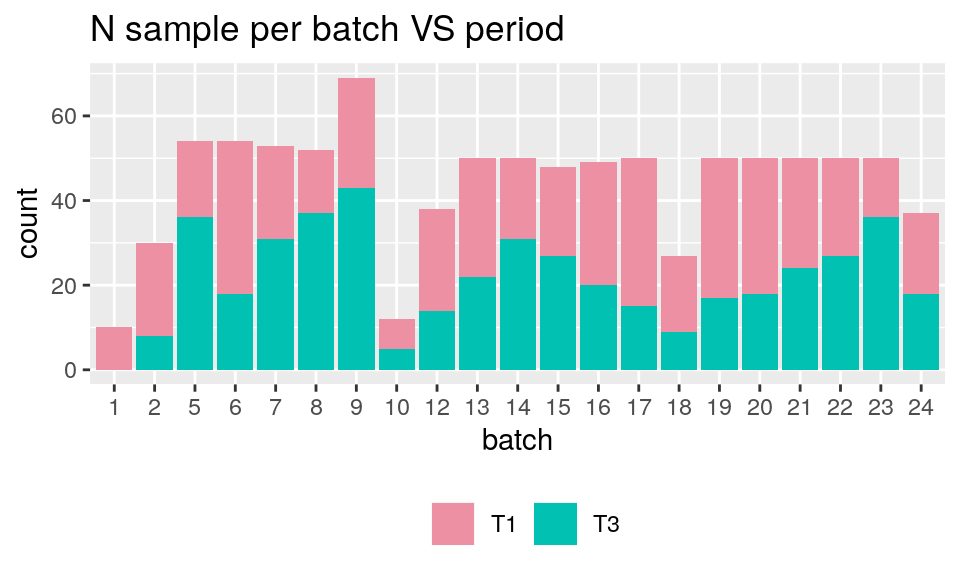

As we have previously seen there is a link between season on many compound levels it is interesting to note season variability between batches:

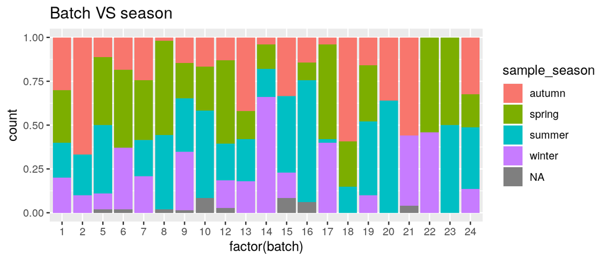

- Batch 17 used as reference because high N, high proportion of “winter” the reference category of the season variable and both present for both phthalates and phenols (code generalisability)

# 3 Defreeze time and transport time

Transport time was log transformed due to strong skewness and defreeze times were used as tertiles because of the outliers that were pulling the trends.

Values below or equal to zero were set to missing then all missing values were imputed to the median.

- N missing defreeze times: 58 / 933
- N missing transport times: 37 / 933

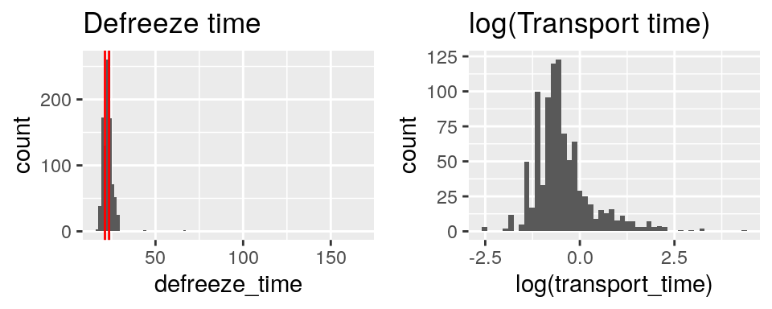

# 4 Associations with protocol vars

## 4.1 DAG

DAG for variables in link with protocol variables.

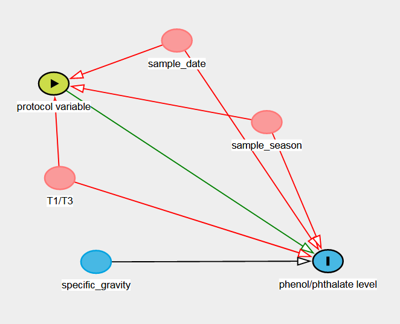

## 4.2 Method

A multiple interval censored linear regression is fit between compound level and the three protocol variables of interest and further adjusted on known confounding factors (cf. DAG + phenols paper):

- `specific_gravity`
- `sample_date` (linear time trend)
- `sample_season` (categorical)
- `period` (T1 vs T3)
- `mom_edu` (categorical)
- `mom_age` (continuous)
- `mom_bmi` (continuous)
- `parity` (continuous)

## 4.3 Model outputs

Here are the p-values for the variables of interest from the multivariate model used to decide which protocol variables to correct for.

p-values in the adjusted regressions

| compound | p_batch | p_def_time | p_trans_time |
| --- | --- | --- | --- |
| cxMiNP | 0 | 0.725 | 0.444 |
| MBzP | 0.19 | 0.079 | 0.614 |
| MECPP | 0 | 0.896 | 0.296 |
| MEHHP | 0.075 | 0.917 | 0.643 |
| MEHP | 0.007 | 0.869 | 0.76 |
| MEOHP | 0.005 | 0.867 | 0.499 |
| MEP | 0.028 | 0.913 | 0.953 |
| MiBP | 0 | 0.366 | 0.387 |
| MMCHP | 0 | 0.663 | 0.748 |
| MnBP | 0.012 | 0.459 | 0.779 |
| ohMINCH | 0 | 0.822 | 0.099 |
| ohMiNP | 0.082 | 0.382 | 0.89 |
| ohMPHP | 0 | 0.268 | 0.823 |
| oxoMINCH | 0 | 0.961 | 0.078 |
| oxoMiNP | 0.006 | 0.71 | 0.757 |